# Ejercicio Python de Regresión Lineal + coeficiente de correlacion

Mario José Arrieta Sánchez

Predecir la venta del mes 7 dada las ventas de meses anteriores

Enero - 7000, Febrero - 9000, Marzo - 5000, Abril - 11000, Mayo - 10000, Junio - 13000

Ahora procederemos a cargar los datos, donde x son cada mes, las y cada venta

```python
##Listas de datos
x=[1,2,3,4,5,6]
y=[7000,9000,5000,11000,10000,13000]
```

Ahora importamos las librerías necesarias

```python
#libreria para manejar datos numericos
import numpy as np
#libreria para graficar
import matplotlib
import matplotlib.pyplot as plt
```

Convertimos los datos de tipo lista a Array, también calculamos algunas sumatoria que nos pide la ecuación

```python
n=len(x)#tamaño del arreglo

#convertimos a arreglos
y=np.array(y)
x=np.array(x)
#sumatoria de las ventas
sumy=sum(y)
#sumatoria de los meses
sumx=sum(x)
#sumatoria de los meses al cuadrado
sumx2=sum(x*x)
sumy2=sum(y*y)
#sumatoria de la multiplicacion entre xy
sumxy=sum(x*y)
#promedio de ventas y promedio de meses
mediay=sumy/n
mediax=sumx/n
#la suma elevada al cuadrado
suma2x=pow(sumx,2)
```

Ahora miraremos la ecuación de la Regresión lineal $Y_t=a+bx$ , donde $a$ es el punto de intersección y $b$ la pendiente Siendo $Y_t$ el valor que queremos predecir

Nota: Ecuación de la pendiente:

$b=\frac{n\sum_{i=1}^{n}y_{i}x_{i}- \sum_{i=1}^{n}y_{i}\sum_{i=1}^{n}x_{i}}{n\sum_{i=1}^{n}x_{i}^2 - (\sum_{i=1}^{n}x_{i})^2}$

Ecuación del punto de intersección:

$a=\frac{\sum_{i=1}^{n}y_i}{n}-b(\frac{\sum_{i=1}^{n}x_i}{n})$

```python
##aqui comenzamos la regression lineal
#calculamos la pendiente
pendiente=((n*sumxy)-(sumx*sumy))/((n*sumx2)- suma2x)
#interseccion
interseccion=mediay-(pendiente*mediax)
##prediccion del 7 mes
prediccion=interseccion+(pendiente*7)
print ('la prediccion de la venta para el 7 mes es:')
print (prediccion)
```

```
la prediccion de la venta para el 7 mes es:
13066.666666666666
```

Ahora solo nos faltaria graficar:

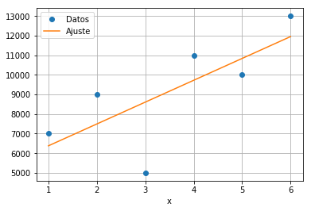

```python
plt.plot(x,y,'o', label='Datos')
plt.plot(x, pendiente*x + interseccion, label='Ajuste')
plt.xlabel('t')
plt.xlabel('x')
plt.grid()
plt.legend()
```

Teniendo la predicción de la venta del 7 mes y la representación gráfica, ahora solo falta calcular el coeficiente de correlación entre las variables X,Y para conocer su dependencia.

Ecuación de Coeficiente de correlación de Pearson: $r_{xy}=\frac{\sigma_{xy}}{\sigma_x \sigma_y}$

Donde:

$\sigma_{xy}$ es la covarianza de $x,y$

$\sigma_{xy}=\frac{\sum_{i=1}^{n}xy}{n}-(\frac{\sum_{i=1}^{n}x}{n})(\frac{\sum_{i=1}^{n}y}{n})$

$\sigma_x$ es la desviación típica de la variable x

$\sigma_x=\sqrt{\frac{(\sum_{i=1}^{n}x^2)}{n}- (\frac{\sum_{i=1}^{n}x}{n})^2}$

$\sigma_y$ es la desviación típica de la variable y

$\sigma_y=\sqrt{\frac{(\sum_{i=1}^{n}y^2)}{n}- (\frac{\sum_{i=1}^{n}y}{n})^2}$

Por último se debe elevar el $r_{xy}$ al cuadrado $(r_{xy})^2$

```python
mediax2=pow(mediax,2)
mediay2= pow(mediay,2)

sigmax= np.sqrt((sumx2/n) - mediax2)
sigmay= np.sqrt((sumy2/n) - mediay2)
sigmaxy=(sumxy/n) - (mediax*mediay)
r=(sigmaxy/(sigmax*sigmay));
r2=pow(r,2)
print('Coeficiente de correacion')
print(r2)
plt.show()
```

```
Coeficiente de correacion
0.5321282798833822
```